# CompSciX 415.2 Homework 3

##### 2- Width and height control the amount of jittering

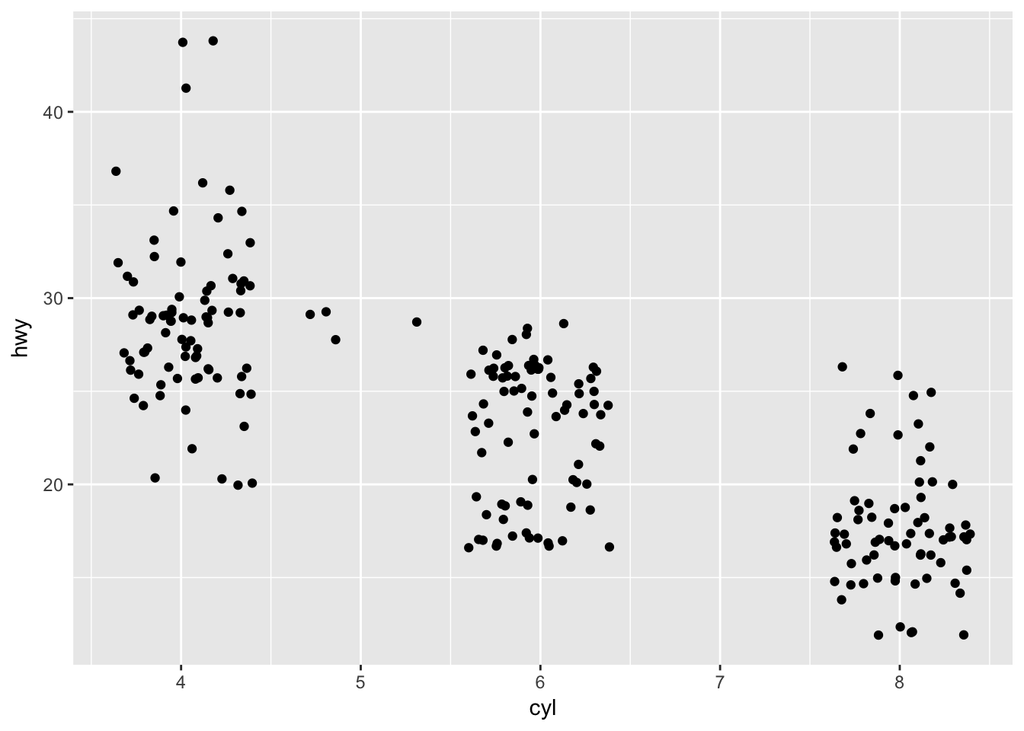

```r
?geom_jitter
ggplot(mpg, aes(cyl, hwy)) + geom_jitter()
```

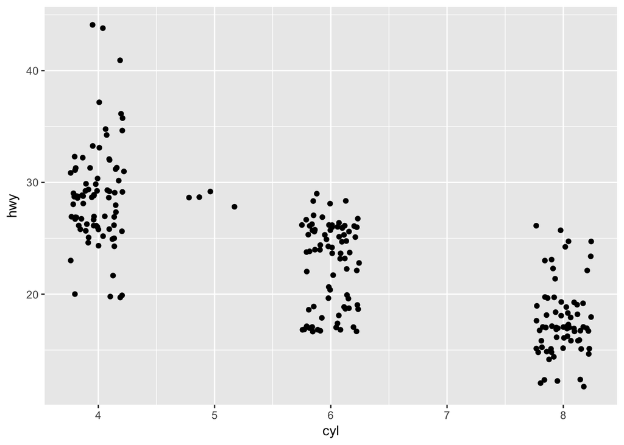

```r
ggplot(mpg, aes(cyl, hwy)) + geom_jitter(width = 0.25)
```

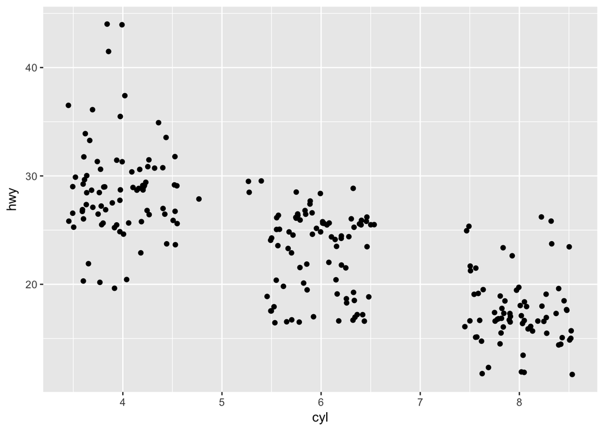

```r
ggplot(mpg, aes(cyl, hwy)) + geom_jitter(width = 0.55, height = 0.55)
```

#####-3 “geom_count” is a variant geom_point that counts the number of observations at each location, then maps the count to point area. It useful when you have discrete data and overplotting. #####The jitter geom is a convenient shortcut for geom_point(position = “jitter”). It adds a small amount of random variation to the location of each point, and is a useful way of handling overplotting caused by discreteness in smaller datasets. As you can see below geom_count reveals more information abojut overlapping data.

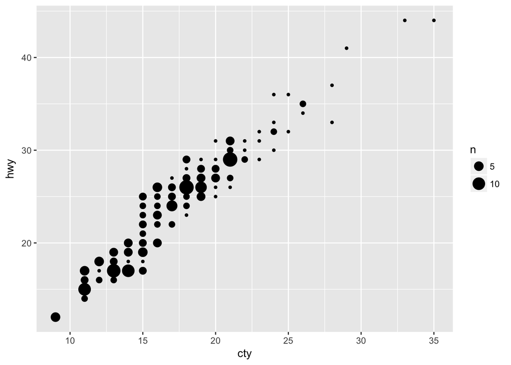

```r
?geom_count
ggplot(mpg, aes(cty, hwy)) +
 geom_count()
```

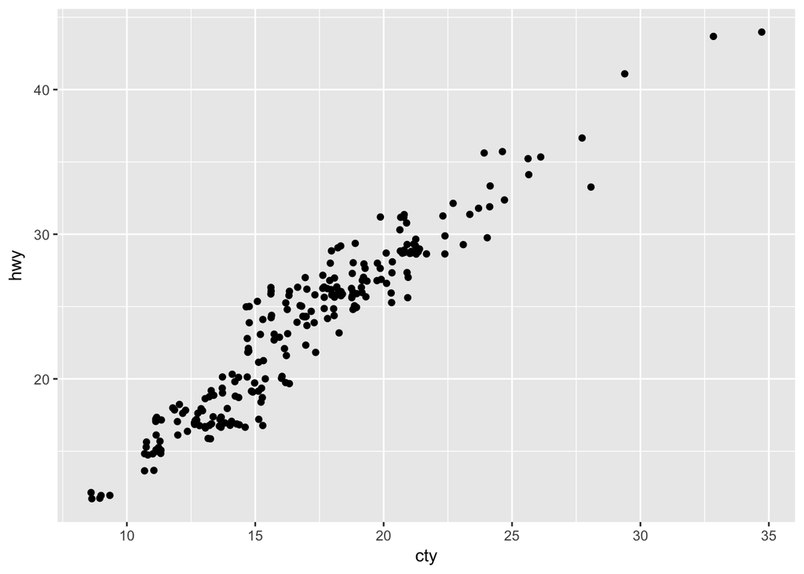

```r
ggplot(mpg, aes(cty, hwy)) +
 geom_jitter()
```

#####4 Position adjustment, either as a string, or the result of a call to a position adjustment function.

##### Defual position for boxplot is “dodge”

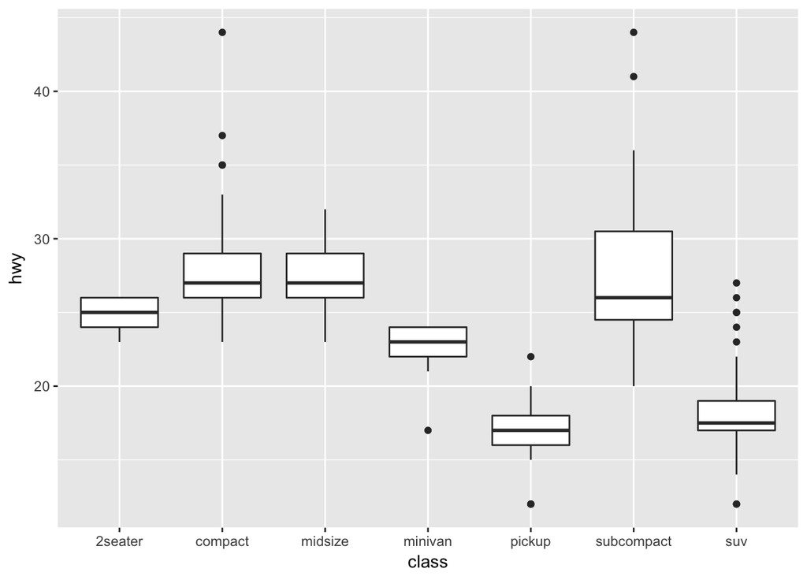

```r
?geom_boxplot
ggplot(mpg, aes(class, hwy)) + geom_boxplot()
```

### Answers to Question in 3.9.1

##### 2- Modify axis, legend, and plot labels. Good labels are critical for making your plots accessible to a wider audience. Ensure the axis and legend labels display the full variable name.

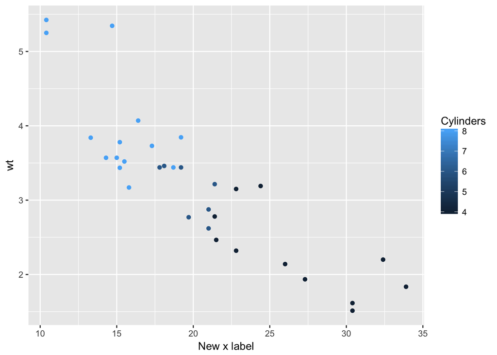

```r
?labs()
ggplot(mtcars, aes(mpg, wt, colour = cyl)) + geom_point() + labs(colour = "Cylinders") + labs(x = "New x label")
```

#####4- geom_abline adds reference line (sometimes called rules) to a plot, either horizontal, vertical, or diagonal (specified by slope and intercept). These are useful for annotating plots. #####fixed scale coordinate system forces a specified ratio between the physical representation of data units on the axes. The ratio represents the number of units on the y-axis equivalent to one unit on the x-axis. The default, ratio = 1, ensures that one unit on the x-axis is the same length as one unit on the y-axis. Ratios higher than one make units on the y axis longer than units on the x-axis, and vice versa. coord_fixed is important to get a better visual of the data when both axis have the same measurment

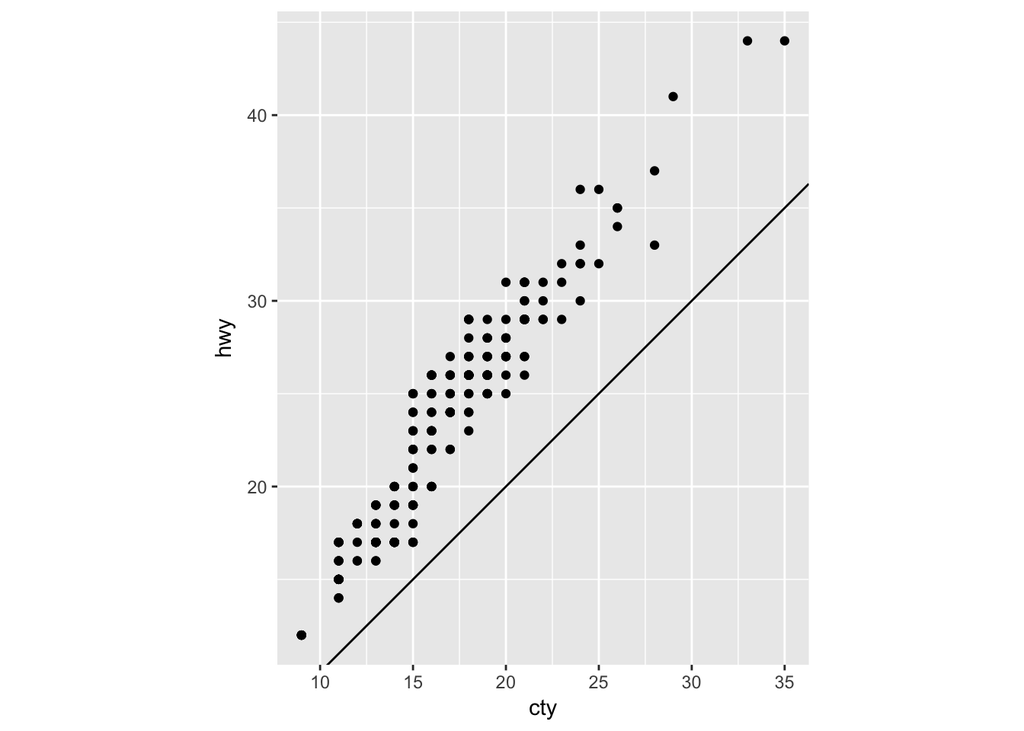

```r
ggplot(data = mpg, mapping = aes(x = cty, y = hwy)) +
  geom_point() +
  geom_abline() +
  coord_fixed()
```

```r
?geom_abline
?coord_fixed
```